# IFX_2022 - Project - Tx_Baseline

PSS RFS DR RF PTE PRE

2025-07-04

##### IFX_2022 - Project - Tx_Baseline

# 1 Background_overview

## 1.1 Base_line_overview.pdf

[figure not shown]

## 1.2 Deep_dive_MUC_v0_general overview of Baseline.pdf

[figure not shown]

## 1.3 PAM2p0_Steering_2022-09-29_slides.pdf

[figure not shown]

## 1.4 TX_Baseline_overview_Jan_2023.pdf

[figure not shown]

# 2 Design

## 2.1 Reference_prj_PLP3839

### 2.1.1 DocumentsPrematch design PLP3839.pdf

[figure not shown]

## 2.2 Reference_material_PPT

### 2.2.1 Module Design Rules and Procedures.pdf

[figure not shown]

## 2.3 libraries

### 2.3.1 Minipac Building Blocks - Workflow guide v1p0.pdf

[figure not shown]

## 2.4 Specifications

### 2.4.1 5G_Frontend_requirements_PAM2p0+_external_2v1.pdf

[figure not shown]

## 2.5 Simulations

### 2.5.3 Build_1_DOE1

#### 2.5.3.1 DOE1_12mm_T9095A_1 _P1p5dB_Refined.pdf

[figure not shown]

### 2.5.4 Build_2c

#### 2.5.4.1 Assembly Design review minipac build 2C.pdf

[figure not shown]

#### 2.5.4.2 Build 2c_Lgit_vs_Access_fwdBW_vs_revBW.pdf

[figure not shown]

### 2.5.5 Build_3_DOE6

#### 2.5.5.1 Chip_n_wire_12mm_T9095A_1 _P1p5dB_15042022.pdf

[figure not shown]

### 2.5.6 Build_4_DOE7

#### 2.5.6.1 2p4mm_T9507B_2_design 10052022.pdf

[figure not shown]

#### 2.5.6.2 Design Review_Theepak.pdf

[figure not shown]

### 2.5.7 Build_5_DOE9

#### 2.5.7.1 Build_5_11p52mm_R9505_A 25052022.pdf

[figure not shown]

### 2.5.8 Build_6_DOE11

#### 2.5.8.1 Build_6_3p84mm_P13_T9504_A 12072022.pdf

[figure not shown]

### 2.5.9 Build_7_DOE13

#### 2.5.9.1 Build_7_6p4mm_R9505_A 12072022.pdf

[figure not shown]

### 2.5.10 Build_8_DOE15

#### 2.5.10.1 Build_8_DOE15_LDMOS_T6083A_TIMCAL2_6x380um_design_29072022.pdf

[figure not shown]

#### 2.5.10.2 DOE15_R6051A_BPCM_3_6X400um_2p4mm_re-design.pdf

[figure not shown]

### 2.5.11 Build_8_DOE16_Theepak

#### 2.5.11.1 DOE16_R6051A_BPCM_3_8X400um_3p2mm_re-design.pdf

[figure not shown]

#### 2.5.12.1 Build_9_DOE17_T9501R_2p4mm_T9501_R_11082022.pdf

[figure not shown]

## 2.6 Study

### 2.6.1 Via effect on bondpads.pdf

[figure not shown]

# 3 Measurements

## 3.1 Build_1_DOE1_Anteverta_Meas.pdf

[figure not shown]

## 3.2 Overview

### 3.2.1 DOE4_5_FOCUS vs ANT comparison.pdf

[figure not shown]

## 3.3 LP_optimzation_Procedure

### 3.3.1 Baseline Loadpull for Comparison of LDMOS & GaN MINIPAC.pdf

[figure not shown]

## 3.4 Test_Fixture

### 3.4.1 Minipac_fixture.pdf

[figure not shown]

### 3.4.2 IFX_Nijmegen_test_fixture.pdf

[figure not shown]

## 3.5 Down_selection

### 3.5.1 DOEs measurement strategy.pdf

[figure not shown]

### 3.5.2 DOE_3 Downselection.pdf

[figure not shown]

### 3.5.3 DOE4 Downselection.pdf

[figure not shown]

### 3.5.4 DOE5 Downselection.pdf

[figure not shown]

### 3.5.5 DOE6 Downselection.pdf

[figure not shown]

### 3.5.6 DOE6_2 class_C.pdf

[figure not shown]

### 3.5.7 DOE8 Downselection v2.pdf

[figure not shown]

### 3.5.8 DOE9 Downselection.pdf

[figure not shown]

### 3.5.9 DOE12 Downselection.pdf

[figure not shown]

### 3.5.10 DOE14 Downselection.pdf

[figure not shown]

### 3.5.11 DOE15 Downselection.pdf

[figure not shown]

### 3.5.12 Main_selection.PNG

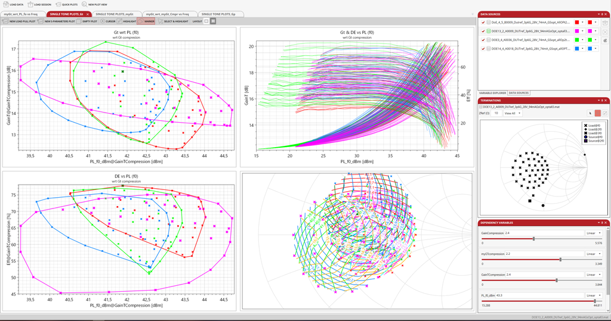

10_Main_selection.PNG

# 4 Model

## 4.1 Timeline.png

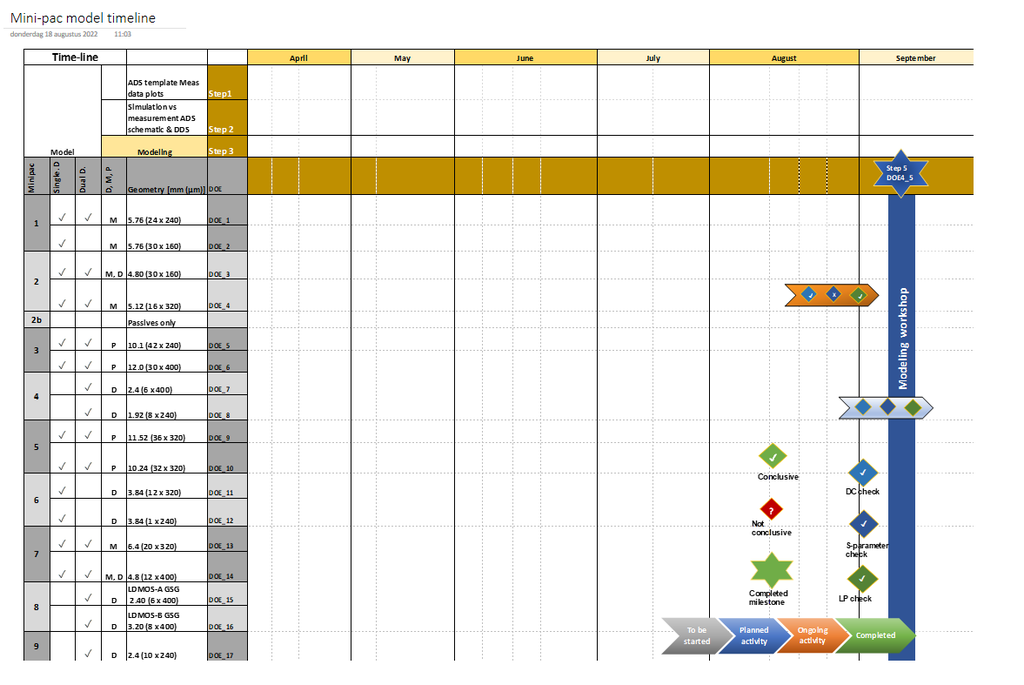

01_Timeline.png

## 4.2 20230509 rfGaN_X1_P11A_V2.pdf

[figure not shown]

## 4.3 Workshop

### 4.3.1 ADS template

#### 4.3.1.2 Comparison of the LP Simulation and Focus LP.pdf

[figure not shown]

### 4.3.2 Model flow

#### 4.3.2.1 Model tuning flow.pdf

[figure not shown]

### 4.3.4 ADS_library_wrkspace

#### 4.3.4.2 Tx_Baseline_Model_library.pdf

[figure not shown]

### 4.3.5 workshop PPTs

#### 4.3.5.1 ~$00_Model_workshop_Agenda.pptx

[figure not shown]

#### 4.3.5.2 ~$01_Introduction to Modeling_session_1.pptx

[figure not shown]

#### 4.3.5.3 ~$02_2022-04-07 Model alignment with MINIPAC status_session 2.pptx

[figure not shown]

#### 4.3.5.4 ~$03_Mini_pac_D&A_session_3.pptx

[figure not shown]

#### 4.3.5.5 ~$03_Mini_pac_Design & Assembly_session_3.pptx

[figure not shown]

#### 4.3.5.6 ~$04_Mini_pac_Measurements & Model_session_4.pptx

[figure not shown]

#### 4.3.5.7 ~$05_ADS template user guide_session_5.pptx

[figure not shown]

#### 4.3.5.8 ~$07_Wrapup_Conclusion_session_7.pptx

[figure not shown]

#### 4.3.5.9 Model_workshop_Agenda.pdf

[figure not shown]

#### 4.3.5.10 Introduction to Modeling_session_1.pdf

[figure not shown]

#### 4.3.5.11 2022-04-07 Model alignment with MINIPAC status_session 2.pdf

[figure not shown]

#### 4.3.5.12 Mini_pac_Design & Assembly_session_3.pdf

[figure not shown]

#### 4.3.5.13 Mini_pac_Measurements & Model_session_4.pdf

[figure not shown]

#### 4.3.5.14 ADS template user guide_session_5.pdf

[figure not shown]

#### 4.3.5.15 Wrapup_Conclusion_session_7.pdf

[figure not shown]

### 4.3.6 Rgb_Minipac_verification

#### 4.3.6.1 Report.pdf

[figure not shown]

# 5 Assembly

## 5.1 Cross_section_Access

### 5.1.1 Cross_section_FA_analysis.pdf

[figure not shown]

## 5.2 Mold_compound

### 5.2.1 Hitachi GE100LFC-K.pdf

[figure not shown]

### 5.2.2 TDS for G355.pdf

[figure not shown]

## 5.3 Design_Rules

### 5.3.2 MiniPac design rule_Frank.pptx

[figure not shown]

### 5.3.3 Access

#### 5.3.3.1 Bar Via design guide line supplier.pdf

[figure not shown]

### 5.3.4 LGIT

#### 5.3.4.1 Design_Rules_Amkor_SiP_RevO (002).pdf

[figure not shown]

#### 5.3.4.2 LGIT design rule_2021_IFX.pdf

[figure not shown]

## 5.4 Drawing

### 5.4.1 Review

#### 5.4.1.1 AD minipac build 10.pdf

[figure not shown]

#### 5.4.1.2 AD review minipac build 6.pdf

[figure not shown]

#### 5.4.1.3 AD review minipac build 7.pdf

[figure not shown]

#### 5.4.1.4 AD review minipac build 8.pdf

[figure not shown]

#### 5.4.1.5 AD review minipac build 9.pdf

[figure not shown]

#### 5.4.1.6 Build2 DoE_3 DoE_4 Wire Bonding.pdf

[figure not shown]

#### 5.4.1.7 Build3 DoE_5 DoE_6 Wire Bonding.pdf

[figure not shown]

#### 5.4.1.8 Build4 DoE_7 DoE_8 Wire Bonding.pdf

[figure not shown]

#### 5.4.1.9 DoE_2_ Wire Bonding.pdf

[figure not shown]

#### 5.4.1.10 DoE_2b_Wire Bonding.pdf

[figure not shown]

### 5.4.2 Assembly_plan

#### 5.4.2.1 Assembly plan minipac study build 1 V2p0.pdf

[figure not shown]

### 5.4.3 AD

#### 5.4.3.1 LAC3839_DEEMB_assembly_lib__LAC3839_R9514A_1236_LD_DOE1_1.pdf

[figure not shown]

#### 5.4.3.2 LAC3839_DEEMB_assembly_lib__LAC3839_R9514A_1236_OP_DOE1_2.pdf

[figure not shown]

#### 5.4.3.3 LAC3839_DEEMB_assembly_lib__LAC3839_R9514A_1236_SH_DOE1_3.pdf

[figure not shown]

#### 5.4.3.4 LAC3839_DEEMB_assembly_lib__LAC3839_R9514A_1236_TH_DOE1_4.pdf

[figure not shown]

#### 5.4.3.5 LAC3839_DEEMB_assembly_lib__LAC3839_R9514A_CAL_ATT_DOE1_5.pdf

[figure not shown]

#### 5.4.3.6 LAC3839_DEEMB_assembly_lib__LAC3839_R9514A_PAM_11_B_4P8_DOE2_1.pdf

[figure not shown]

#### 5.4.3.7 LAC3839_DEEMB_assembly_lib__LAC3839_R9514A_PAM_11_TH_DOE3_1.pdf

[figure not shown]

#### 5.4.3.8 LAC3839_DEEMB_assembly_lib__LAC3839_R9514A_PAM_12_B_5P6_DOE2_2.pdf

[figure not shown]

## 5.5 FA

### 5.5.1 Report_FA.pdf

[figure not shown]

### 5.5.2 vi23s1-00668.pdf

[figure not shown]

# 6 Minipac_V02

## 6.1 Flow Chart of the MiniPac.pdf

[figure not shown]

## 6.2 Minipac_V2.pdf

[figure not shown]

# 7 PCB-pac

## 7.1 20230412 TX module baseline results.pdf

[figure not shown]